# Project Foundations for Data Science: FoodHub Data Analysis

**Marks: 60**

### Context

The number of restaurants in New York is increasing day by day. Lots of students and busy professionals rely on those restaurants due to their hectic lifestyles. Online food delivery service is a great option for them. It provides them with good food from their favorite restaurants. A food aggregator company FoodHub offers access to multiple restaurants through a single smartphone app.

The app allows the restaurants to receive a direct online order from a customer. The app assigns a delivery person from the company to pick up the order after it is confirmed by the restaurant. The delivery person then uses the map to reach the restaurant and waits for the food package. Once the food package is handed over to the delivery person, he/she confirms the pick-up in the app and travels to the customer's location to deliver the food. The delivery person confirms the drop-off in the app after delivering the food package to the customer. The customer can rate the order in the app. The food aggregator earns money by collecting a fixed margin of the delivery order from the restaurants.

### Objective

The food aggregator company has stored the data of the different orders made by the registered customers in their online portal. They want to analyze the data to get a fair idea about the demand of different restaurants which will help them in enhancing their customer experience. Suppose you are hired as a Data Scientist in this company and the Data Science team has shared some of the key questions that need to be answered. Perform the data analysis to find answers to these questions that will help the company to improve the business.

### Data Description

The data contains the different data related to a food order. The detailed data dictionary is given below.

### Data Dictionary

- order_id: Unique ID of the order
- customer_id: ID of the customer who ordered the food
- restaurant_name: Name of the restaurant
- cuisine_type: Cuisine ordered by the customer
- cost: Cost of the order
- day_of_the_week: Indicates whether the order is placed on a weekday or weekend (The weekday is from Monday to Friday and the weekend is Saturday and Sunday)
- rating: Rating given by the customer out of 5
- food_preparation_time: Time (in minutes) taken by the restaurant to prepare the food. This is calculated by taking the difference between the timestamps of the restaurant's order confirmation and the delivery person's pick-up confirmation.
- delivery_time: Time (in minutes) taken by the delivery person to deliver the food package. This is calculated by taking the difference between the timestamps of the delivery person's pick-up confirmation and drop-off information

### Let us start by importing the required libraries

```python
# import libraries for data manipulation
import numpy as np
import pandas as pd

# import libraries for data visualization
import matplotlib.pyplot as plt
import seaborn as sns
```

### Understanding the structure of the data

```python
# read the data
df = pd.read_csv("data/foodhub_order.csv")
# returns the first 5 rows
df.head()
```

|  | order_id | customer_id | restaurant_name | cuisine_type | cost_of_the_order | day_of_the_week | rating | food_preparation_time | delivery_time |
| --- | --- | --- | --- | --- | --- | --- | --- | --- | --- |
| 0 | 1477147 | 337525 | Hangawi | Korean | 30.75 | Weekend | Not given | 25 | 20 |
| 1 | 1477685 | 358141 | Blue Ribbon Sushi Izakaya | Japanese | 12.08 | Weekend | Not given | 25 | 23 |
| 2 | 1477070 | 66393 | Cafe Habana | Mexican | 12.23 | Weekday | 5 | 23 | 28 |
| 3 | 1477334 | 106968 | Blue Ribbon Fried Chicken | American | 29.20 | Weekend | 3 | 25 | 15 |
| 4 | 1478249 | 76942 | Dirty Bird to Go | American | 11.59 | Weekday | 4 | 25 | 24 |

#### Observations:

The DataFrame has 9 columns as mentioned in the Data Dictionary. Data in each row corresponds to the order placed by a customer.

### **Question 1:** How many rows and columns are present in the data? [0.5 mark]

```python
# Write your code here
# Find the shape of the dataframe
df.shape
```

```
(1898, 9)
```

#### Observations:

The DataFrame has 1898 rows (data points) and 9 columns (features).

### **Question 2:** What are the datatypes of the different columns in the dataset? (The info() function can be used) [0.5 mark]

```python
# Use info() to print a concise summary of the DataFrame
df.info()
```

```
<class 'pandas.core.frame.DataFrame'>
RangeIndex: 1898 entries, 0 to 1897
Data columns (total 9 columns):
 #   Column                 Non-Null Count  Dtype
---  ------                 --------------  -----
 0   order_id               1898 non-null   int64
 1   customer_id            1898 non-null   int64
 2   restaurant_name        1898 non-null   object
 3   cuisine_type           1898 non-null   object
 4   cost_of_the_order      1898 non-null   float64
 5   day_of_the_week        1898 non-null   object
 6   rating                 1898 non-null   object
 7   food_preparation_time  1898 non-null   int64
 8   delivery_time          1898 non-null   int64
dtypes: float64(1), int64(4), object(4)
memory usage: 133.6+ KB
```

#### Observations:

The dataset contains 5 numeric columns and 4 object columns.

The numeric columns are:

- `order_id`
- `customer_id`
- `cost_of_the_order`
- `food_preparation_time`
- `delivery_time`

The object columns are:

- `restaurant_name`
- `cuisine_type`
- `day_of_the_week`
- `rating`

### **Question 3:** Are there any missing values in the data? If yes, treat them using an appropriate method. [1 mark]

```python
# Write your code here
# Compute the sum of NA values in each column of the dataframe
df.isna().sum()
```

```
order_id                 0
customer_id              0
restaurant_name          0
cuisine_type             0
cost_of_the_order        0
day_of_the_week          0
rating                   0
food_preparation_time    0
delivery_time            0
dtype: int64
```

#### Observations:

There are no missing values in the data and so no actions are needed to remove or impute the dataset.

### **Question 4:** Check the statistical summary of the data. What is the minimum, average, and maximum time it takes for food to be prepared once an order is placed? [2 marks]

```python
# Write your code here
# Find the description of the numeric columns of the dataframe
df.describe()
```

|  | order_id | customer_id | cost_of_the_order | food_preparation_time | delivery_time |
| --- | --- | --- | --- | --- | --- |
| count | 1.898000e+03 | 1898.000000 | 1898.000000 | 1898.000000 | 1898.000000 |
| mean | 1.477496e+06 | 171168.478398 | 16.498851 | 27.371970 | 24.161749 |
| std | 5.480497e+02 | 113698.139743 | 7.483812 | 4.632481 | 4.972637 |
| min | 1.476547e+06 | 1311.000000 | 4.470000 | 20.000000 | 15.000000 |
| 25% | 1.477021e+06 | 77787.750000 | 12.080000 | 23.000000 | 20.000000 |
| 50% | 1.477496e+06 | 128600.000000 | 14.140000 | 27.000000 | 25.000000 |
| 75% | 1.477970e+06 | 270525.000000 | 22.297500 | 31.000000 | 28.000000 |
| max | 1.478444e+06 | 405334.000000 | 35.410000 | 35.000000 | 33.000000 |

```python
# Find the description of the non-numeric columns of the dataframe
df.describe(exclude=[np.number])
```

|  | restaurant_name | cuisine_type | day_of_the_week | rating |
| --- | --- | --- | --- | --- |
| count | 1898 | 1898 | 1898 | 1898 |
| unique | 178 | 14 | 2 | 4 |
| top | Shake Shack | American | Weekend | Not given |
| freq | 219 | 584 | 1351 | 736 |

#### Observations:

Once the order is placed, the minimum, average, and maximum time for food to be prepared are 20, ~27.37, and 35 minutes respectively.

### **Question 5:** How many orders are not rated? [1 mark]

```python
# Write the code here
# Compute the count of each rating
df["rating"].value_counts()
```

```
rating
Not given    736
5            588
4            386
3            188
Name: count, dtype: int64
```

#### Observations:

There are 736 out of the 1898 orders that are not rated.

### Exploratory Data Analysis (EDA)

### **Question 6:** Explore all the variables and provide observations on their distributions. (Generally, histograms, boxplots, countplots, etc. are used for univariate exploration.) [9 marks]

```python
# Get the unique restaurants on the app and the number of times they received orders
rest_counts = df["restaurant_name"].value_counts()
print(f"Number of unique restaurants are {len(rest_counts)}")

top_rests = df[df["restaurant_name"].isin(rest_counts[rest_counts >= 5].index)]
top_rest_counts = top_rests["restaurant_name"].value_counts()
print(f"Number of restaurants with only one order: {len(rest_counts[rest_counts == 1])}")
print(f"Number of restaurants with < 5 orders: {len(rest_counts[rest_counts < 5])}")
print(f"Number of restaurants with >= 5 orders: {len(rest_counts[rest_counts >= 5])}")

# Get the mean and median statistics of all restaurants
all_rest_mean = round(rest_counts.mean(), 2)
all_rest_median = rest_counts.median()

# Get the mean and median statistics of restaurants with >= 5 orders
top_rest_mean = round(top_rest_counts.mean(), 2)
top_rest_median = top_rest_counts.median()

print(f"Mean of all restaurants: {all_rest_mean}")
print(f"Median of all restaurants: {all_rest_median}")
print(f"Mean of top restaurants: {top_rest_mean}")
print(f"Median of top restaurants: {top_rest_median}")

top_rest_counts
```

```
Number of unique restaurants are 178
Number of restaurants with only one order: 50
Number of restaurants with < 5 orders: 109
Number of restaurants with >= 5 orders: 69
Mean of all restaurants: 10.66
Median of all restaurants: 3.0
Mean of top restaurants: 24.36
Median of top restaurants: 13.0
```

```
restaurant_name
Shake Shack                  219
The Meatball Shop            132
Blue Ribbon Sushi            119
Blue Ribbon Fried Chicken     96
Parm                          68
                            ...
Mission Cantina                5
5 Napkin Burger                5
Vezzo Thin Crust Pizza         5
Pylos                          5
Tony's Di Napoli               5
Name: count, Length: 69, dtype: int64
```

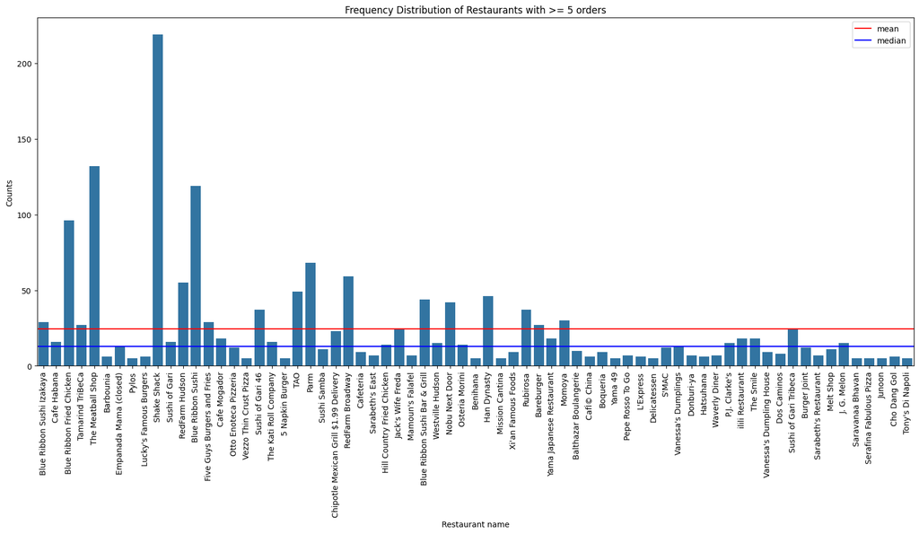

```python
# Plot the frequency distribution of restaurants with >= 5 orders
fig, ax = plt.subplots(figsize=(20, 8))
plt.xticks(rotation=90)
sns.countplot(data=top_rests, x="restaurant_name", ax=ax)
ax.axhline(top_rest_counts.mean(), color="red", label="mean")
ax.axhline(top_rest_counts.median(), color="blue", label="median")
ax.set(title="Frequency Distribution of Restaurants with >= 5 orders", xlabel="Restaurant name", ylabel="Counts")
plt.legend()
plt.show()
```

### Observation

There are 178 unique restaurants in the dataset which is difficult to visualize clearly in a plot. Therefore, we used the filtering criteria of restaurants with >= 5 orders to plot, as shown above, of which there is 69 restaurants. The top 5 restaurants in the entire dataset in terms of the number of orders are:

- Shake Shack
- The Meatball Shop
- Blue Ribbon Sushi
- Blue Ribbon Fried Chicken
- Parm

Finally, the mean and median counts of all restaurants are 10.66 and 3, respectively and the minimum and maximum counts are 1 and 219, respectively.

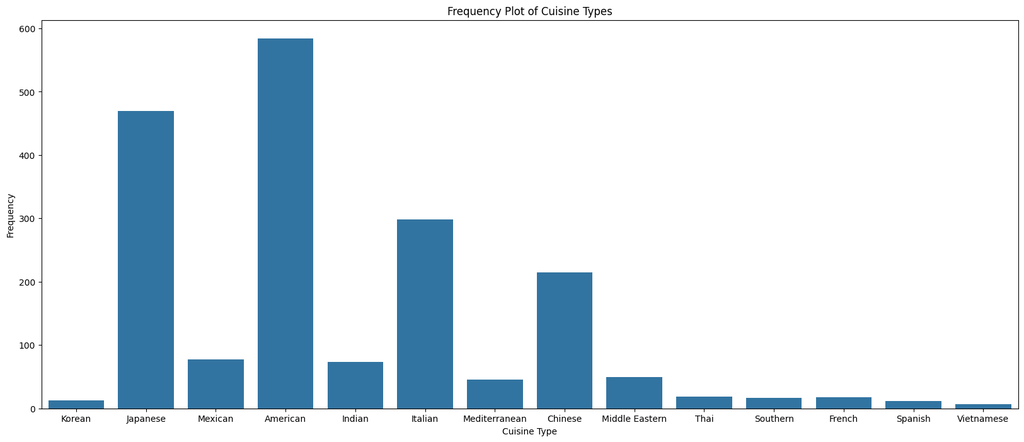

```python
# Frequency plot for different cuisine types
fig, ax = plt.subplots(figsize=(20, 8))
sns.countplot(df, x="cuisine_type", ax=ax)
ax.set(title="Frequency Plot of Cuisine Types", xlabel="Cuisine Type", ylabel="Frequency")
plt.show()
```

```python
# Determine some quantitative information about cuisine types
cuisine_type_counts = df["cuisine_type"].value_counts()
print(f"Number of cuisine types on FoodHub is: {len(cuisine_type_counts)}")
cuisine_type_counts
```

```
Number of cuisine types on FoodHub is: 14
```

```
cuisine_type
American          584
Japanese          470
Italian           298
Chinese           215
Mexican            77
Indian             73
Middle Eastern     49
Mediterranean      46
Thai               19
French             18
Southern           17
Korean             13
Spanish            12
Vietnamese          7
Name: count, dtype: int64
```

### Observation

There are 14 different cuisine types on FoodHub. The three most popular cuisine types on FoodHub in terms of number of orders are:

- American
- Japanese
- Italian

while the three least popular cuisine types are:

- Korean
- Spanish
- Vietnamese

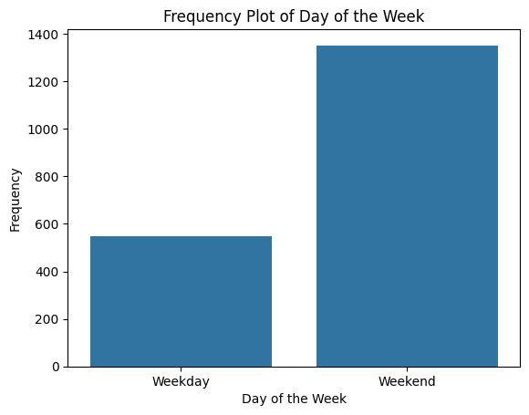

```python
# Frequency plot of the number of orders on weekdays and weekends
sns.countplot(x=df["day_of_the_week"].sort_values());
plt.title("Frequency Plot of Day of the Week")
plt.xlabel("Day of the Week")
plt.ylabel("Frequency")
plt.show()
```

```python
# Some quantitative information about the day of the week
df["day_of_the_week"].value_counts()
```

```
day_of_the_week
Weekend    1351
Weekday     547
Name: count, dtype: int64
```

### Observation

There are more orders that are placed on the weekend (1351) compared to the weekday (547). An interesting observation is that nearly 2.5 times as many orders are placed on weekends.

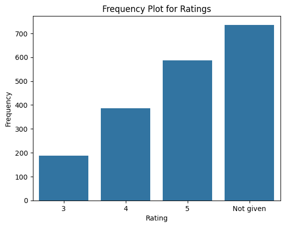

```python
# Frequency plot of food ratings
sns.countplot(x=df["rating"].sort_values());
plt.title("Frequency Plot for Ratings")
plt.xlabel("Rating")
plt.ylabel("Frequency")
plt.show()
```

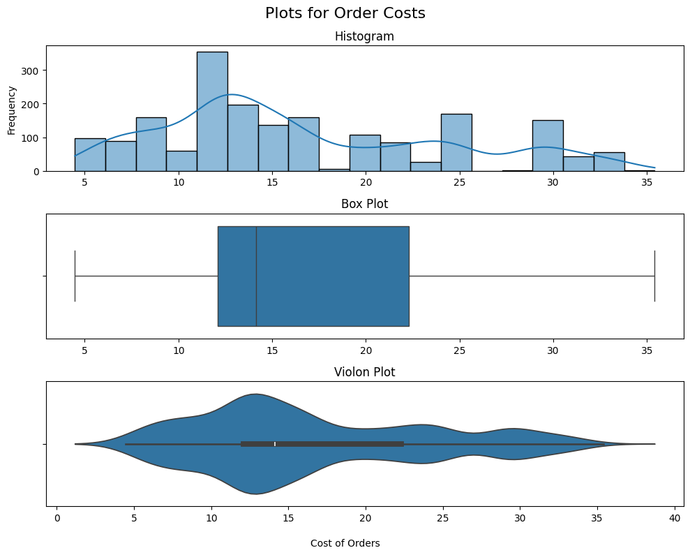

```python
# Data visualization for the cost of orders
fig, axes = plt.subplots(nrows=3, ncols=1, figsize=(10, 8))

sns.histplot(data=df, x="cost_of_the_order", ax=axes[0], kde=True)
axes[0].set(title="Histogram", xlabel="", ylabel="Frequency")

sns.boxplot(data=df, x="cost_of_the_order", ax=axes[1])
axes[1].set(title="Box Plot", xlabel="", ylabel="")

sns.violinplot(data=df, x="cost_of_the_order", ax=axes[2])
axes[2].set(title="Violon Plot", xlabel="", ylabel="")

fig.suptitle("Plots for Order Costs", fontsize=16)
fig.supxlabel("Cost of Orders", fontsize=10)
plt.tight_layout()
```

```python
# Determine some quantitative information about order costs
df["cost_of_the_order"].describe()
```

```
count    1898.000000
mean       16.498851
std         7.483812
min         4.470000
25%        12.080000
50%        14.140000
75%        22.297500
max        35.410000
Name: cost_of_the_order, dtype: float64
```

### Observation

From the above plots, the `cost_of_the_order` feature has positive skew (right-skewed) with minimum, average, and maximum prices of $4.47, $16.5, $35.41.

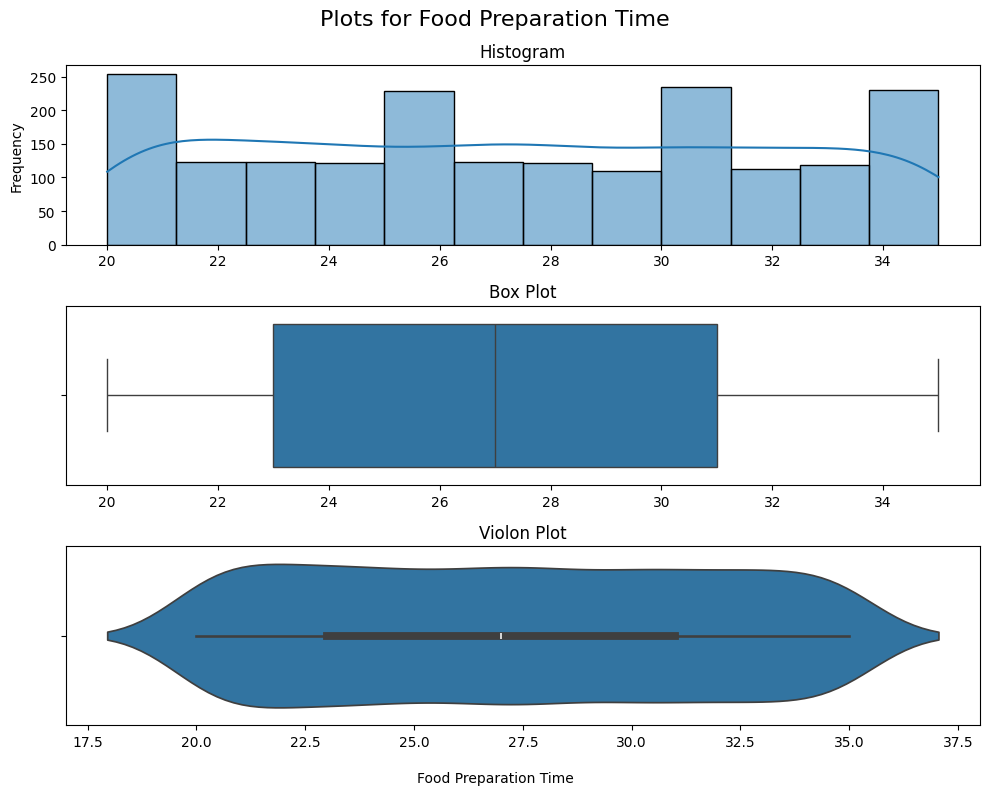

```python
# Data visualization for the time to prepare food
fig, axes = plt.subplots(nrows=3, ncols=1, figsize=(10, 8))

sns.histplot(data=df, x="food_preparation_time", ax=axes[0], kde=True)
axes[0].set(title="Histogram", xlabel="", ylabel="Frequency")

sns.boxplot(data=df, x="food_preparation_time", ax=axes[1])
axes[1].set(title="Box Plot", xlabel="", ylabel="")

sns.violinplot(data=df, x="food_preparation_time", ax=axes[2])
axes[2].set(title="Violon Plot", xlabel="", ylabel="")

fig.suptitle("Plots for Food Preparation Time", fontsize=16)
fig.supxlabel("Food Preparation Time", fontsize=10)
plt.tight_layout()
```

```python
# Determine some quantitative information about food preparation time
df["food_preparation_time"].describe()
```

```
count    1898.000000
mean       27.371970
std         4.632481
min        20.000000
25%        23.000000
50%        27.000000
75%        31.000000
max        35.000000
Name: food_preparation_time, dtype: float64
```

### Observation

From the above plots, the time to prepare food is relatively symmetric around its mean and there is no skew in the data with minimum, average, and maximum time to prepare food of 20, ~27.37, 35 minutes. It is interesting to note that the spikes in the above plots occur at the tail values as well as two central values, which suggests that the time to prepare food varies uniformly with a few locations of increased probability.

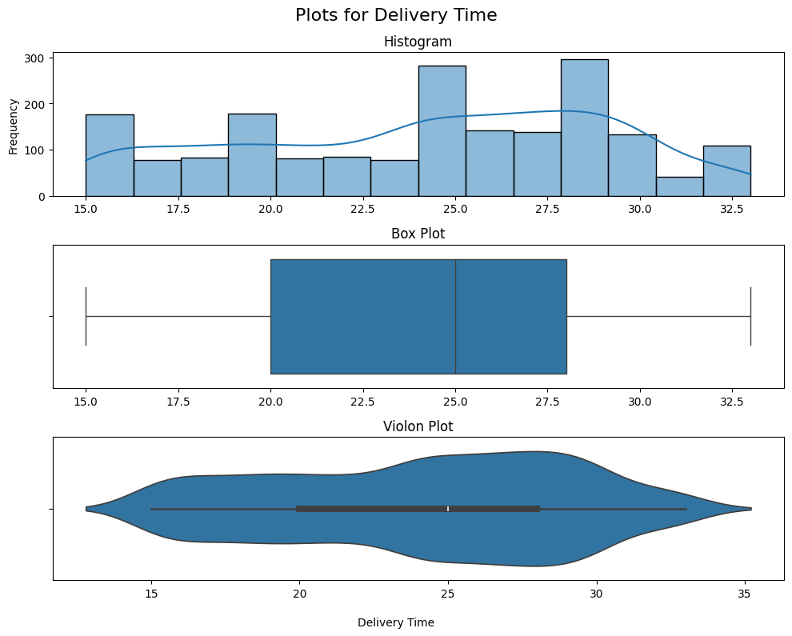

```python
# Data visualization for the time to deliver an order
fig, axes = plt.subplots(nrows=3, ncols=1, figsize=(10, 8))

sns.histplot(data=df, x="delivery_time", ax=axes[0], kde=True)
axes[0].set(title="Histogram", xlabel="", ylabel="Frequency")

sns.boxplot(data=df, x="delivery_time", ax=axes[1])
axes[1].set(title="Box Plot", xlabel="", ylabel="")

sns.violinplot(data=df, x="delivery_time", ax=axes[2])
axes[2].set(title="Violon Plot", xlabel="", ylabel="")

fig.suptitle("Plots for Delivery Time", fontsize=16)
fig.supxlabel("Delivery Time", fontsize=10)
plt.tight_layout()
```

```python
# Determine some quantitative information about the time to delivery an order
df["delivery_time"].describe()
```

```
count    1898.000000
mean       24.161749
std         4.972637
min        15.000000
25%        20.000000
50%        25.000000
75%        28.000000
max        33.000000
Name: delivery_time, dtype: float64
```

### Observation

From the above plots, the time to delivery food has a slight negative skew (left-skewed) with minimum, average, and maximum times of 15, ~24.16, 33 minutes. The delivery time distribution above also suggests that the most common amount of time to delivery an order is between 25 minutes and 30 minutes, which does not seem unreasonable in a city like NYC.

### **Question 7**: Which are the top 5 restaurants in terms of the number of orders received? [1 mark]

```python
# Write the code here
# Find the top five most frequent restaurant in the dataframe
df["restaurant_name"].value_counts().head(5)
```

```
restaurant_name
Shake Shack                  219
The Meatball Shop            132
Blue Ribbon Sushi            119
Blue Ribbon Fried Chicken     96
Parm                          68
Name: count, dtype: int64
```

#### Observations:

The top 5 restaurants in terms of the number of orders received are:

- Shake Shack (219 orders)
- The Meatball Shop (132 orders)
- Blue Ribbon Sushi (119 orders)
- Blue Ribbon Fried Chicken (96 orders)
- Parm (68 orders)

### **Question 8**: Which is the most popular cuisine on weekends? [1 mark]

```python
# Write the code here
# Find the top cuisine type order on the weekend
df[df["day_of_the_week"] == "Weekend"]["cuisine_type"].value_counts().head(1)
```

```
cuisine_type
American    415
Name: count, dtype: int64
```

#### Observations:

The most popular cuisine on weekends is American with 415 orders on the weekend.

### **Question 9**: What percentage of the orders cost more than 20 dollars? [2 marks]

```python
# Write the code here
# Find the amount of orders that cost more than $20
over_20 = df[df["cost_of_the_order"] > 20]
len(over_20) / len(df)
```

```
0.2924130663856691
```

#### Observations:

Approximately 29.24% of orders cost more than 20 dollars.

### **Question 10**: What is the mean order delivery time? [1 mark]

```python
# Write the code here
# Compute the mean of the delivery_time column
df["delivery_time"].mean()
```

```
24.161749209694417
```

#### Observations:

The mean order delivery time is ~24.16 minutes.

### **Question 11:** The company has decided to give 20% discount vouchers to the top 3 most frequent customers. Find the IDs of these customers and the number of orders they placed. [1 mark]

```python
# Write the code here
# Find the top three most frequent customers
df["customer_id"].value_counts().head(3)
```

```
customer_id
52832    13
47440    10
83287     9
Name: count, dtype: int64
```

#### Observations:

The customer IDs and number of orders of the top 3 most frequent customers are:

- ID 52832 with 13 orders
- ID 47440 with 10 orders
- ID 83287 with 9 orders

### **Question 12**: Perform a multivariate analysis to explore relationships between the important variables in the dataset. (It is a good idea to explore relations between numerical variables as well as relations between numerical and categorical variables) [10 marks]

```python
# Write the code here
# Create a copy of the dataframe to process and modify the data
clean_df = df.copy()

# Drop columns from the dataframe that is not useful to analyze
cols_to_drop = ["order_id", "customer_id"]
clean_df.drop(cols_to_drop, axis=1, inplace=True)

# Convert the columns with datatype of object to category
cols_to_convert = ["restaurant_name", "cuisine_type", "day_of_the_week", "rating"]
clean_df[cols_to_convert] = clean_df[cols_to_convert].astype("category")

# Add a new column total_time = food_preparation_time + delivery_time
clean_df["total_time"] = clean_df["food_preparation_time"] + clean_df["delivery_time"]

# Create a copy of the clone dataframe with only rated restaurants
rated_df = clean_df.copy()
rated_df = rated_df[rated_df["rating"] != "Not given"]
rated_df["rating"] = rated_df["rating"].cat.remove_unused_categories().astype(int)
```

```python
# Get the description of each column for the cleaned dataframe
clean_df.describe()
```

|  | cost_of_the_order | food_preparation_time | delivery_time | total_time |
| --- | --- | --- | --- | --- |
| count | 1898.000000 | 1898.000000 | 1898.000000 | 1898.000000 |
| mean | 16.498851 | 27.371970 | 24.161749 | 51.533720 |
| std | 7.483812 | 4.632481 | 4.972637 | 6.833603 |
| min | 4.470000 | 20.000000 | 15.000000 | 35.000000 |
| 25% | 12.080000 | 23.000000 | 20.000000 | 47.000000 |
| 50% | 14.140000 | 27.000000 | 25.000000 | 52.000000 |
| 75% | 22.297500 | 31.000000 | 28.000000 | 56.000000 |
| max | 35.410000 | 35.000000 | 33.000000 | 68.000000 |

```python
# Helper functions for plotting common layouts between multiple variables
def basic_num_cat_plots(data, x, y, title):
    fig, axes = plt.subplots(nrows=1, ncols=3, sharey=True, figsize=(30, 15))

    sns.boxplot(data=data, x=x, y=y, ax= axes[0])
    sns.violinplot(data=data, x=x, y=y, ax= axes[1])
    sns.stripplot(data=data, x=x, y=y, size=3, ax=axes[2], jitter=True)

    fig.suptitle(title)

    plt.tight_layout()
    plt.show()

def hist_num_cat_plot(data, x, y, nrows, ncols, title):
    fig, axes = plt.subplots(nrows=nrows, ncols=ncols, sharey=True, figsize=(20, 8))
    axes = axes.ravel()
    for i, val in enumerate(data[y].unique()):
        sns.histplot(data=data[data[y] == val], x=x, kde=True, ax=axes[i])
        axes[i].set(title=f"{val} vs {x}", xlabel=x)
    fig.suptitle(title)
    plt.tight_layout()
    plt.show()
```

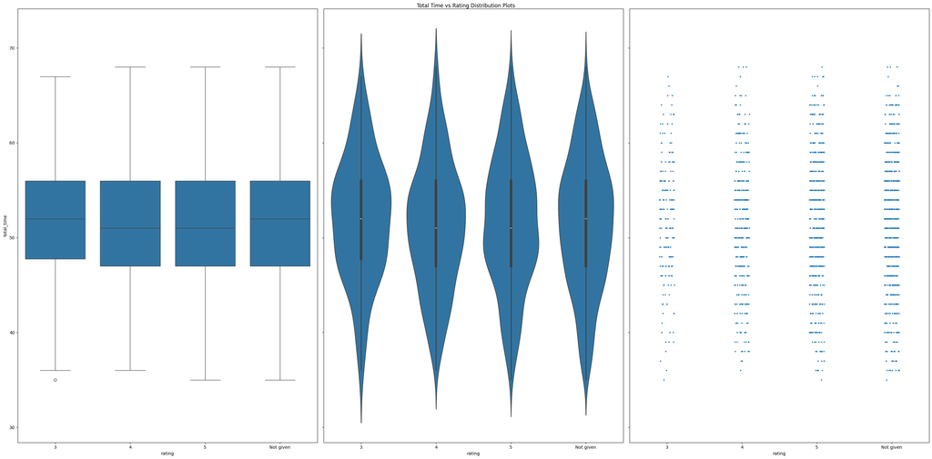

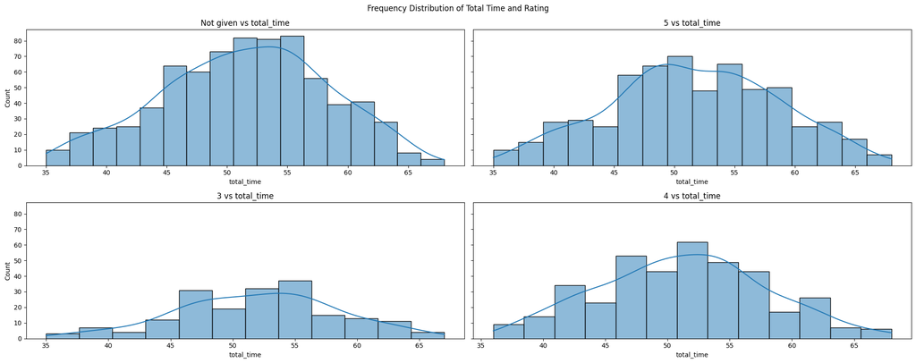

```python
# Visualize the relationship between rating and the total time it takes to reach the customer
basic_num_cat_plots(data=clean_df, x="rating", y="total_time", title="Total Time vs Rating Distribution Plots")
hist_num_cat_plot(data=clean_df, x="total_time", y="rating", nrows=2, ncols=2, title="Frequency Distribution of Total Time and Rating")
```

### Observation

There seems to be no correlation between the total time it takes an order to reach a customer and the customer's rating of the order. This seems reasonable since most customers typically would not judge their order based on how long it takes for the food to arrive unless the time it takes is unacceptably long. In our dataset the maximum total time is 68 minutes, which is reasonable. Therefore this relation is not surprising. It should also be noted that each frequency plot follows a normal distribution.

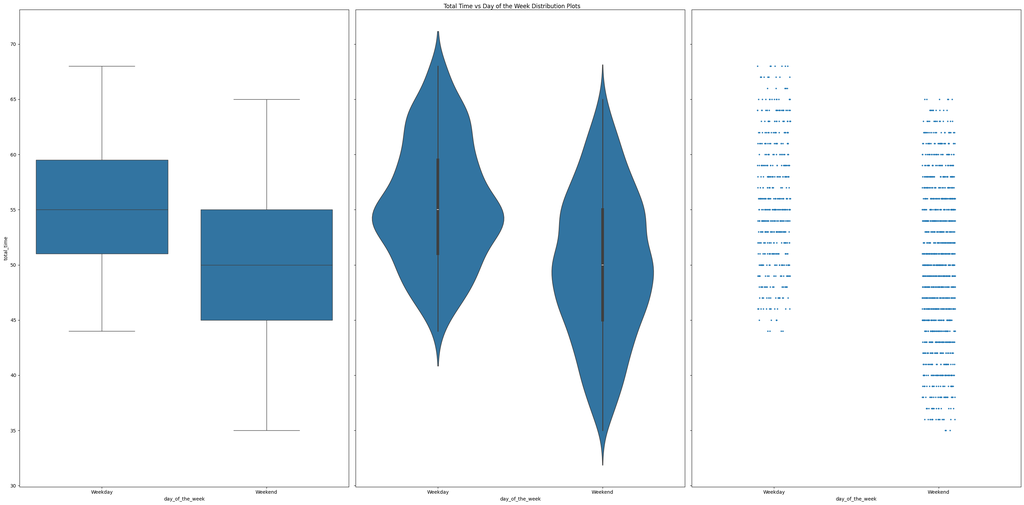

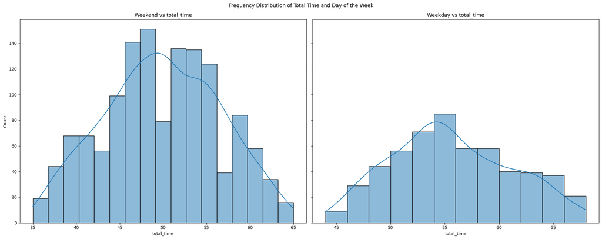

```python
basic_num_cat_plots(data=clean_df, x="day_of_the_week", y="total_time", title="Total Time vs Day of the Week Distribution Plots")
hist_num_cat_plot(data=clean_df, x="total_time", y="day_of_the_week", nrows=1, ncols=2, title="Frequency Distribution of Total Time and Day of the Week")
```

### Observation

The above plots show that the number of orders on weekends is much greater than that on weekdays. However, the minimum, average, and maximum total time on the weekends for orders to arrive to the customer are less than that on the weekdays. This is not surprising as there is typically more traffic on weekdays compared to weekends due to working hours. Furthermore, there is typically a tendency for customers to order less on weekdays as a means to save on unnecessary costs. Furthermore, it should be noted that the total time is takes for an order to be delivered on weekdays and weekends seem to follow a normal distribution.

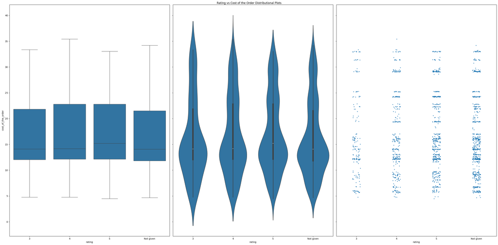

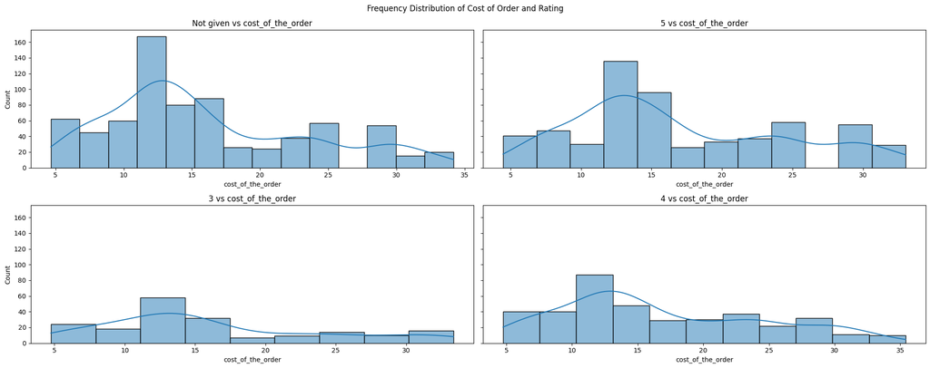

```python
# Visualize the relationship between rating and the cost of the order
basic_num_cat_plots(data=clean_df, x="rating", y="cost_of_the_order", title="Rating vs Cost of the Order Distributional Plots")
hist_num_cat_plot(data=clean_df, x="cost_of_the_order", y="rating", nrows=2, ncols=2, title="Frequency Distribution of Cost of Order and Rating")
```

### Observation

From the above plots, there seems to be no correlation between the cost of an order and its rating. The frequency plots follow the same underlying shaped curve and the distributional plots all have fairly similar summary statistic values, with minute deviations.

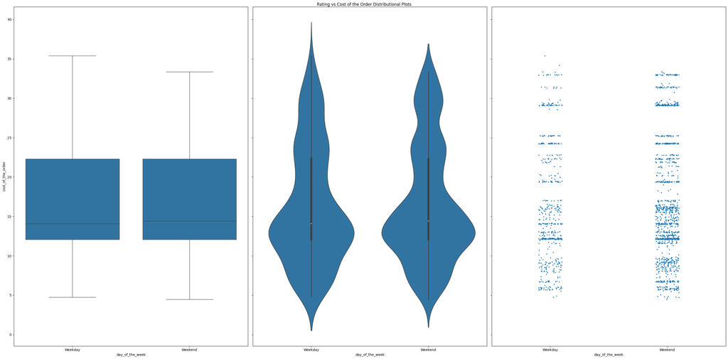

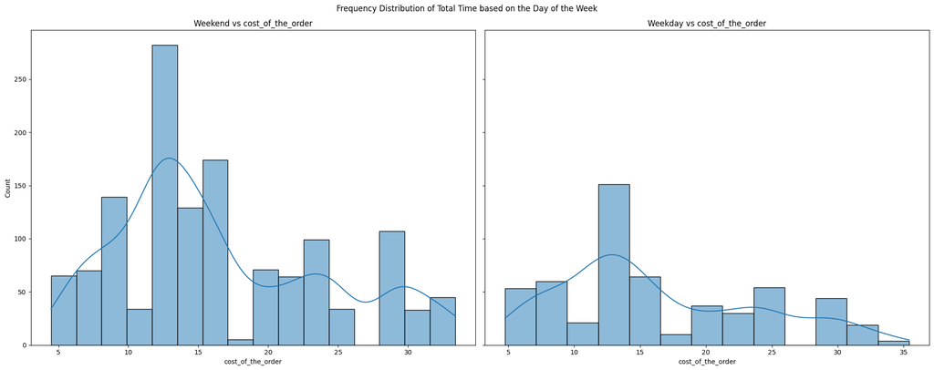

```python
# Visualize the relationship between day of the week and the cost of the order
basic_num_cat_plots(data=clean_df, x="day_of_the_week", y="cost_of_the_order", title="Rating vs Cost of the Order Distributional Plots")
hist_num_cat_plot(data=clean_df, x="cost_of_the_order", y="day_of_the_week", nrows=1, ncols=2, title="Frequency Distribution of Total Time based on the Day of the Week")
```

```python
# Some quantitive information about the cost of orders on different types of days
print("Description of the cost of orders on weekdays")
print(clean_df[clean_df["day_of_the_week"] == "Weekday"]["cost_of_the_order"].describe())

print()

print("Description of the cost of orders on weekends")
print(clean_df[clean_df["day_of_the_week"] == "Weekend"]["cost_of_the_order"].describe())
```

```
Description of the cost of orders on weekdays
count    547.000000
mean      16.311188
std        7.479521
min        4.750000
25%       12.080000
50%       14.070000
75%       22.285000
max       35.410000
Name: cost_of_the_order, dtype: float64

Description of the cost of orders on weekends
count    1351.000000
mean       16.574833
std         7.486979
min         4.470000
25%        12.080000
50%        14.410000
75%        22.285000
max        33.370000
Name: cost_of_the_order, dtype: float64
```

### Observation

The above plots and description indicates that the cost of orders remains the same during the weekend and the weekday. The main reason for analyzing these two features is to determine if restaurants charge additional fees for weekend vs weekday orders, which they do not.

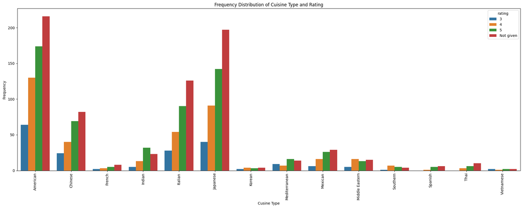

```python
plt.figure(figsize=(20, 8))
sns.countplot(data=clean_df, x="cuisine_type", hue="rating")
plt.xticks(rotation=90)
plt.title("Frequency Distribution of Cuisine Type and Rating")
plt.xlabel("Cusine Type")
plt.ylabel("Frequency")
plt.tight_layout()
plt.show()
```

```python
# Some quantitve analysis between cuisine types and rating
ctype_df = clean_df.groupby("cuisine_type", observed=False)
print("Description of cuisines included unrated orders")
print("-----------------------------------------------")
ctype_df["rating"].describe()
```

```
Description of cuisines included unrated orders
-----------------------------------------------
```

| cuisine_type | count | unique | top | freq |
| --- | --- | --- | --- | --- |
| American | 584 | 4 | Not given | 216 |
| Chinese | 215 | 4 | Not given | 82 |
| French | 18 | 4 | Not given | 8 |
| Indian | 73 | 4 | 5 | 32 |
| Italian | 298 | 4 | Not given | 126 |
| Japanese | 470 | 4 | Not given | 197 |
| Korean | 13 | 4 | 4 | 4 |
| Mediterranean | 46 | 4 | 5 | 16 |
| Mexican | 77 | 4 | Not given | 29 |
| Middle Eastern | 49 | 4 | 4 | 16 |
| Southern | 17 | 4 | 4 | 7 |
| Spanish | 12 | 3 | Not given | 6 |
| Thai | 19 | 3 | Not given | 10 |
| Vietnamese | 7 | 4 | 3 | 2 |

```python
rated_ctype_df = rated_df.groupby("cuisine_type", observed=False)
print("Description of cuisines of only rated orders")
print("--------------------------------------------")
rated_ctype_df["rating"].describe()
```

```
Description of cuisines of only rated orders
--------------------------------------------
```

| cuisine_type | count | mean | std | min | 25% | 50% | 75% | max |
| --- | --- | --- | --- | --- | --- | --- | --- | --- |
| American | 368.0 | 4.298913 | 0.747602 | 3.0 | 4.0 | 4.0 | 5.0 | 5.0 |
| Chinese | 133.0 | 4.338346 | 0.767594 | 3.0 | 4.0 | 5.0 | 5.0 | 5.0 |
| French | 10.0 | 4.300000 | 0.823273 | 3.0 | 4.0 | 4.5 | 5.0 | 5.0 |
| Indian | 50.0 | 4.540000 | 0.676425 | 3.0 | 4.0 | 5.0 | 5.0 | 5.0 |
| Italian | 172.0 | 4.360465 | 0.747906 | 3.0 | 4.0 | 5.0 | 5.0 | 5.0 |
| Japanese | 273.0 | 4.373626 | 0.727329 | 3.0 | 4.0 | 5.0 | 5.0 | 5.0 |
| Korean | 9.0 | 4.111111 | 0.781736 | 3.0 | 4.0 | 4.0 | 5.0 | 5.0 |
| Mediterranean | 32.0 | 4.218750 | 0.870090 | 3.0 | 3.0 | 4.5 | 5.0 | 5.0 |
| Mexican | 48.0 | 4.416667 | 0.709610 | 3.0 | 4.0 | 5.0 | 5.0 | 5.0 |
| Middle Eastern | 34.0 | 4.235294 | 0.698866 | 3.0 | 4.0 | 4.0 | 5.0 | 5.0 |
| Southern | 13.0 | 4.307692 | 0.630425 | 3.0 | 4.0 | 4.0 | 5.0 | 5.0 |
| Spanish | 6.0 | 4.833333 | 0.408248 | 4.0 | 5.0 | 5.0 | 5.0 | 5.0 |
| Thai | 9.0 | 4.666667 | 0.500000 | 4.0 | 4.0 | 5.0 | 5.0 | 5.0 |
| Vietnamese | 5.0 | 4.000000 | 1.000000 | 3.0 | 3.0 | 4.0 | 5.0 | 5.0 |

### Observation

There are a few interesting observations to be noted from the above plots and quantative descriptions.

These observations may be fruitful to further investigate in order to determine which cuisines to promote and demote to new customers as well for onboarding new restaurants.

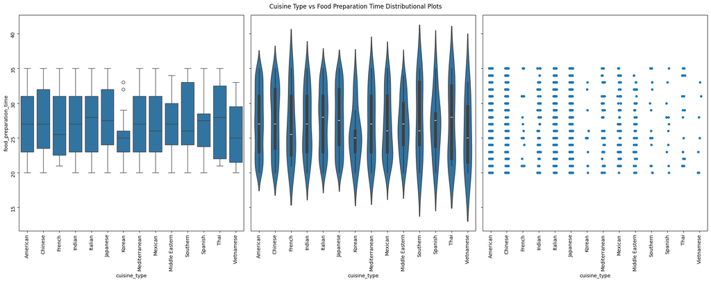

```python
# Visualize the relationship between food preparation time and cuisine type
fig, axes = plt.subplots(nrows=1, ncols=3, sharey=True, figsize=(20, 8))
sns.boxplot(data=clean_df, y="food_preparation_time", x="cuisine_type", ax=axes[0])
axes[0].tick_params(labelrotation=90)
sns.violinplot(data=clean_df, y="food_preparation_time", x="cuisine_type", ax=axes[1])
axes[1].tick_params(labelrotation=90)
sns.stripplot(data=clean_df, y="food_preparation_time", x="cuisine_type", jitter=True, ax=axes[2])
axes[2].tick_params(labelrotation=90)
fig.suptitle("Cuisine Type vs Food Preparation Time Distributional Plots")
plt.tight_layout()
plt.show()
```

```python
# Some quantitative investigation of cuisine type and food preparation time
ctype_df = clean_df.groupby("cuisine_type", observed=False)
print("Description of cuisine food preparation times")
print("---------------------------------------------")
ctype_df["food_preparation_time"].describe()
```

```
Description of cuisine food preparation times
---------------------------------------------
```

| cuisine_type | count | mean | std | min | 25% | 50% | 75% | max |
| --- | --- | --- | --- | --- | --- | --- | --- | --- |
| American | 584.0 | 27.440068 | 4.658474 | 20.0 | 23.00 | 27.0 | 31.0 | 35.0 |
| Chinese | 215.0 | 27.511628 | 4.758525 | 20.0 | 23.50 | 27.0 | 32.0 | 35.0 |
| French | 18.0 | 26.888889 | 5.039712 | 21.0 | 22.50 | 25.5 | 31.0 | 35.0 |
| Indian | 73.0 | 27.109589 | 4.620491 | 20.0 | 23.00 | 27.0 | 31.0 | 35.0 |
| Italian | 298.0 | 27.483221 | 4.519474 | 20.0 | 23.00 | 28.0 | 31.0 | 35.0 |
| Japanese | 470.0 | 27.510638 | 4.604496 | 20.0 | 24.00 | 27.5 | 32.0 | 35.0 |
| Korean | 13.0 | 25.461538 | 3.971049 | 20.0 | 23.00 | 25.0 | 26.0 | 33.0 |
| Mediterranean | 46.0 | 27.000000 | 4.908043 | 20.0 | 23.00 | 27.0 | 31.0 | 35.0 |
| Mexican | 77.0 | 26.727273 | 4.604450 | 20.0 | 23.00 | 26.0 | 31.0 | 35.0 |
| Middle Eastern | 49.0 | 26.673469 | 4.012417 | 20.0 | 24.00 | 27.0 | 30.0 | 34.0 |
| Southern | 17.0 | 27.588235 | 5.523346 | 20.0 | 24.00 | 26.0 | 33.0 | 35.0 |
| Spanish | 12.0 | 26.916667 | 4.501683 | 20.0 | 23.75 | 27.5 | 28.5 | 35.0 |
| Thai | 19.0 | 27.315789 | 5.498006 | 21.0 | 22.00 | 28.0 | 32.5 | 35.0 |
| Vietnamese | 7.0 | 25.714286 | 5.154748 | 20.0 | 21.50 | 25.0 | 29.5 | 33.0 |

### Observation

Most cuisine types have a similar range and mean for food preparation times with a range from 20 minutes to 35 minutes and an average of between 25.5 to 27.5 minutes. Interestingly the Korean cuisine has the smallest range and mean preparation time, however this is only based on 13 orders. Therefore, there does not seems to be any significant correlation between the time to prepare food and the cuisine type.

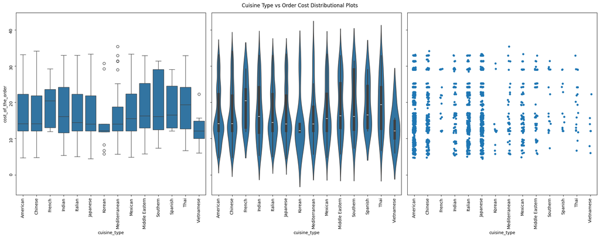

```python
# Visualize the relationship between cost of order and cuisine type
fig, axes = plt.subplots(nrows=1, ncols=3, sharey=True, figsize=(20, 8))
sns.boxplot(data=clean_df, y="cost_of_the_order", x="cuisine_type", ax=axes[0])
axes[0].tick_params(labelrotation=90)
sns.violinplot(data=clean_df, y="cost_of_the_order", x="cuisine_type", ax=axes[1])
axes[1].tick_params(labelrotation=90)
sns.stripplot(data=clean_df, y="cost_of_the_order", x="cuisine_type", jitter=True, ax=axes[2])
axes[2].tick_params(labelrotation=90)
fig.suptitle("Cuisine Type vs Order Cost Distributional Plots")
plt.tight_layout()
plt.show()
```

```python
# Some quantitative investigation of cuisine type and order cost
ctype_df = clean_df.groupby("cuisine_type", observed=False)
print("Description of cuisine order costs")
print("----------------------------------")
ctype_df["cost_of_the_order"].describe()
```

```
Description of cuisine order costs
----------------------------------
```

| cuisine_type | count | mean | std | min | 25% | 50% | 75% | max |
| --- | --- | --- | --- | --- | --- | --- | --- | --- |
| American | 584.0 | 16.319829 | 7.462290 | 4.71 | 12.0800 | 14.120 | 22.2600 | 33.18 |
| Chinese | 215.0 | 16.305209 | 7.631503 | 4.75 | 12.1050 | 14.120 | 21.8800 | 34.19 |
| French | 18.0 | 19.793889 | 6.508990 | 11.98 | 13.0525 | 20.470 | 23.6550 | 29.25 |
| Indian | 73.0 | 16.919726 | 7.897493 | 5.34 | 11.6400 | 16.150 | 24.2000 | 33.03 |
| Italian | 298.0 | 16.418691 | 7.268831 | 5.05 | 12.0800 | 14.480 | 22.2600 | 33.03 |
| Japanese | 470.0 | 16.304532 | 7.422722 | 4.47 | 12.0800 | 14.070 | 21.8300 | 33.37 |
| Korean | 13.0 | 14.001538 | 7.563540 | 5.77 | 11.8400 | 12.180 | 14.0200 | 30.75 |
| Mediterranean | 46.0 | 15.474783 | 7.604720 | 5.67 | 12.0925 | 13.995 | 18.7825 | 35.41 |
| Mexican | 77.0 | 16.933117 | 7.555108 | 4.85 | 12.0800 | 15.570 | 22.3600 | 33.32 |
| Middle Eastern | 49.0 | 18.820612 | 8.086499 | 5.77 | 12.9500 | 16.300 | 25.2700 | 32.93 |
| Southern | 17.0 | 19.300588 | 7.966032 | 7.38 | 12.4700 | 16.110 | 29.1500 | 31.43 |
| Spanish | 12.0 | 18.994167 | 6.658207 | 12.13 | 12.9150 | 16.520 | 24.4925 | 29.10 |
| Thai | 19.0 | 19.207895 | 7.579149 | 6.69 | 12.7100 | 19.350 | 24.2000 | 32.93 |
| Vietnamese | 7.0 | 12.882857 | 5.319623 | 6.01 | 10.0200 | 12.130 | 14.8700 | 22.26 |

### Observation

The above observations may be fruitful for further investigations in the future in order to derive some promotional offers for different cuisine types to gain customer attraction.

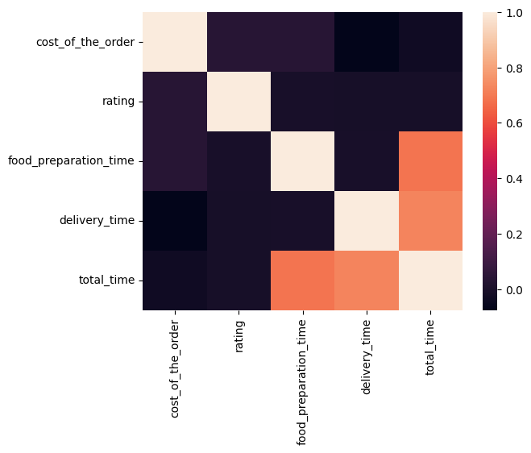

```python
# A heatmap between numeric values
# NOTE: we will use the rated_df here in order to capture relations with the rating column
sns.heatmap(rated_df.corr(numeric_only=True))
plt.show()
```

### **Question 13:** The company wants to provide a promotional offer in the advertisement of the restaurants. The condition to get the offer is that the restaurants must have a rating count of more than 50 and the average rating should be greater than 4. Find the restaurants fulfilling the criteria to get the promotional offer. [3 marks]

```python
# Write the code here
# Create a copy of the dataframe to remove rows with no rating and convert the ratings to integers
clone = df.copy()
clone = clone[clone["rating"] != "Not given"]
clone["rating"] = clone["rating"].astype('int')

# Create GroupBy object based on restuarants
restaurant_group = clone.groupby(["restaurant_name"])
restaurant_ratings = restaurant_group["rating"]

# Select the eligible restaurants with > 50 ratings and an average rating of > 4.
eligible_restaurants = ((restaurant_ratings.count() > 50) & (restaurant_ratings.mean() > 4)).sort_values(ascending=False)

# Select only the rows of eligible restaurants that are True and drop all others
eligible_restaurants[eligible_restaurants == True]
```

```
restaurant_name
Shake Shack                  True
Blue Ribbon Sushi            True
Blue Ribbon Fried Chicken    True
The Meatball Shop            True
Name: rating, dtype: bool
```

#### Observations:

The eligible restaurants fulfilling the criteria to get the promotional offer are:

- Shake Shack
- Blue Ribbon Sushi
- Blue Ribbon Fried Chicken
- The Meatball Shop

### **Question 14:** The company charges the restaurant 25% on the orders having cost greater than 20 dollars and 15% on the orders having cost greater than 5 dollars. Find the net revenue generated by the company across all orders. [3 marks]

```python
# Write the code here
def usage_tax(val):
    if val > 20:
        return val * 0.25
    if val > 5:
        return val * 0.15

df["cost_of_the_order"].apply(usage_tax).sum()
```

```
6166.303
```

#### Observations:

The net revenue generated by the company across all orders after the company charges its usage tax is ~$6166.3.

### **Question 15:** The company wants to analyze the total time required to deliver the food. What percentage of orders take more than 60 minutes to get delivered from the time the order is placed? (The food has to be prepared and then delivered.) [2 marks]

```python
# Write the code here
long_orders = df["food_preparation_time"] + df["delivery_time"] > 60

print(f"Number of long orders: {long_orders.sum()}")
print(f"Percentage of long orders: {long_orders.sum() / len(df)}")
```

```
Number of long orders: 200
Percentage of long orders: 0.1053740779768177
```

#### Observations:

The total number of orders that take more than 60 minutes to get delivered from the time the order is placed is 200. The percentage of such orders in the data is ~10.54%.

### **Question 16:** The company wants to analyze the delivery time of the orders on weekdays and weekends. How does the mean delivery time vary during weekdays and weekends? [2 marks]

```python
# Write the code here
day_of_week = df.groupby(by=["day_of_the_week"])

print(f"Number of orders on weekdays: {len(day_of_week.get_group('Weekday'))}")
print(f"Number of orders on weekends: {len(day_of_week.get_group('Weekend'))}")
day_of_week["delivery_time"].mean()
```

```
Number of orders on weekdays: 547
Number of orders on weekends: 1351
```

```
day_of_the_week
Weekday    28.340037
Weekend    22.470022
Name: delivery_time, dtype: float64
```

#### Observations:

The average delivery time on weekdays is ~28.34 minutes from 547 orders and the average delivery time on weekends is ~22.47 minutes from 1351 orders. So, orders tend to have longer delivery times on weekdays compared to weekends, which may be due to increased traffic on roads due to work hours, especially in a city like New York.

### Conclusion and Recommendations

### **Question 17:** What are your conclusions from the analysis? What recommendations would you like to share to help improve the business? (You can use cuisine type and feedback ratings to drive your business recommendations.) [6 marks]

### Conclusions:

After analyzing the data from FoodHub, there are a few key observations that stood out:

- The app is most often used during the weekends with nearly 2.5x more orders compared to weekdays. Despite the increase in the app's usage, the company is not only able to keep up with the demand but also has a shorted total wait time for the customer to receive their order. Further investigation as to why this is the case may be warranted, however, my opinion on the matter is that people tend to prepare food at home or buy food near their work during the weekdays. The increased amount of time for orders to be received during weekdays may be due to increased traffic during working hours, or that there are less delivery people active during those times as they have other occupations during the week and use the app as a part-time job. Nevertheless, the app seems to be performing well given the demand on both weekdays and weekends.
- The app is lossing out on acquiring useful rating data from its orders. Nearly 40% of all orders are not rated which reduced the company's capability of ranking and recommending restaurants and cuisine types to old and new users. Time and effort should be put into remedying this issue in order to allow the company to improve its systems.
- Most orders tend to range between $10 to $20, with approximately 70% of orders being priced at less than $20. Therefore, promoting high cost dishes may not in general be fruitful to users on FoodHub. In particular, cuisines like French food which have a high average cost may not be the most appropriate for the app.
- The American, Japanese, Italian, and Chinese cuisines are the most popular on the app. These appear to be staples of the types of food users enjoy and promoting them may deem fruitful.
- The Vietnamese cuisine is the worst performing cuisine on the app, with the lowest rating and the lowest number of orders. Simiarly, the Korean cuisine does not seem to be performing well on the app. This may be due to it being a more exotic type of cuisine and less popular compared to Japanese, Chinese, and Thai food. If it costs the company money to keep restaurants, it may be best to remove this cuisines entirely.
- There are some cuisines, such as Spanish, Mexican, and Thai that are well rated considering their lower order numbers. Compared to the other popular cuisines, these seem secondary, however increased exposure to users may cause them to try restaurants serving these cuisines and increase their interest in more niche foods in the future.
- There seems to be no correlation between the data from users on the app, which indicates that there is a sufficiently diverse set of users and restaurants on the app that no overwhelming pattern has emerged to be exploited.

### Recommendations:

- The company should investigate a few options to incentivize users to rate their orders. Perhaps promotional offers or discount codes for a certain number of rated orders while using the app.
- Since the usage of the app is nearly 2.5x less on weekdays compared to weekends, perhaps the comapny can look into adding promotional or discount codes during weekdays to incentive users to use the app more. This needs to be done careful as to not loss out on revenue from the excessive usage of discounts.
- The company should look into removing or reducing the Vietnamese, Korean, and French cuisine restaurants on the app if it costs them to money to maintain them on the app.
- The company should look into increasing expsoure for cuisines that have low order counts but high ratings in order to have users explore niche foods and potentially use the app more often for their exploration and in turn improving overall app usage and company revenue.
- The company may find it useful in developing a recommendation system between customers with similar food interests in order to improve user experience and perhaps also restaurant ratings (which can lead to more user interactions).